# Técnica de análisis no supervisado con K-Means

#### Análisis entre edad y notas malas

**age + failures**

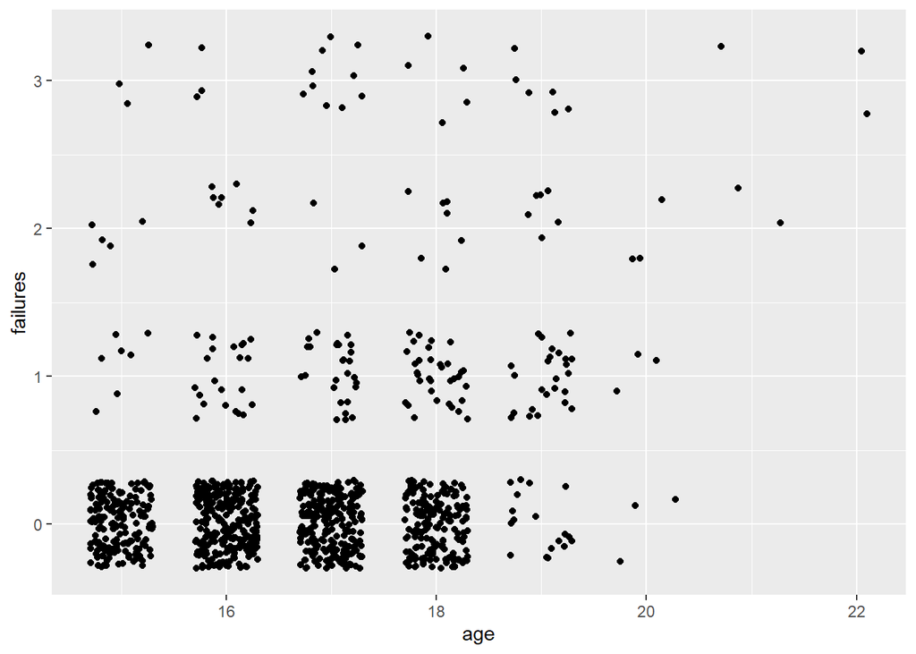

```r
plot3 <- ggplot (data,aes (x=age,y=failures)) +
geom_point ( position=position_jitter ( w=0.3,h=0.3) )
plot3
```

```r
round(tapply ( data$failures,data$age,mean ),1)
```

```
##  15  16  17  18  19  20  21  22
## 0.1 0.2 0.2 0.3 1.0 1.0 2.3 3.0
```

**Análisis entre walc + g3**

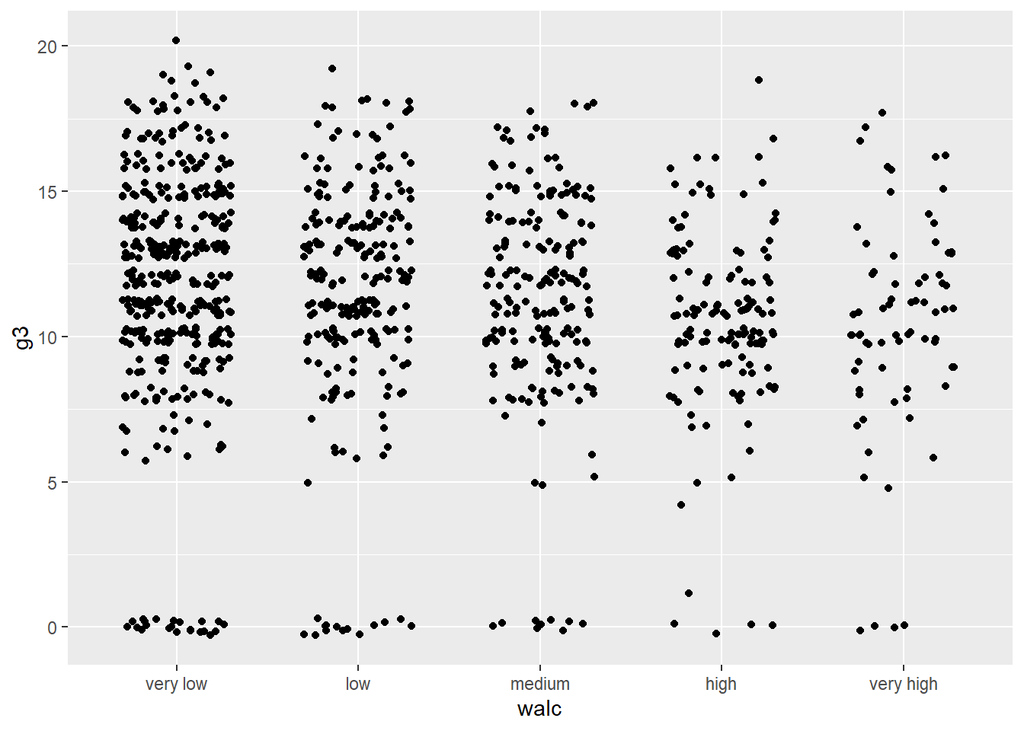

```r
plot4 <- ggplot (data,aes (x=walc,y=g3)) +
geom_point ( position=position_jitter ( w=0.3,h=0.3) )
plot4
```

```r
round(tapply ( data$g3,data$walc,mean ),1)
```

```
##  very low       low    medium      high very high
##      11.7      11.5      11.3      10.5      10.4
```

**Análisis entre dalc + g3**

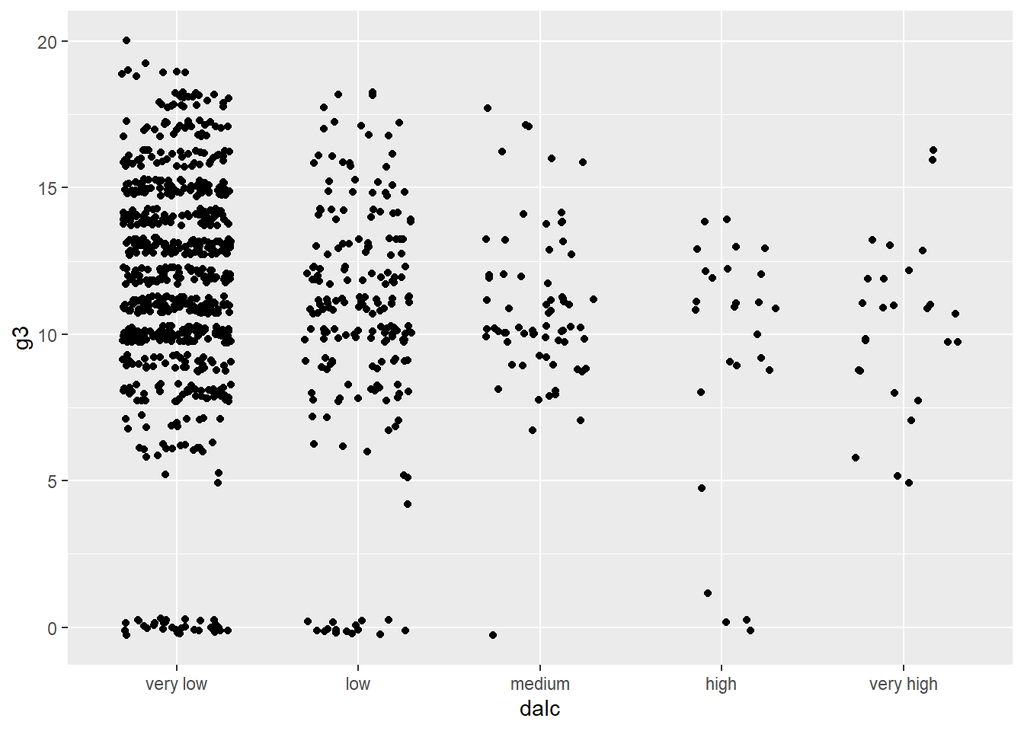

```r
plot5 <- ggplot (data,aes (x=dalc,y=g3)) +
geom_point ( position=position_jitter ( w=0.3,h=0.3) )
plot5
```

```r
round(tapply ( data$g3,data$dalc,mean ),1)
```

```
##  very low       low    medium      high very high
##      11.7      10.6      10.9       9.3      10.4
```

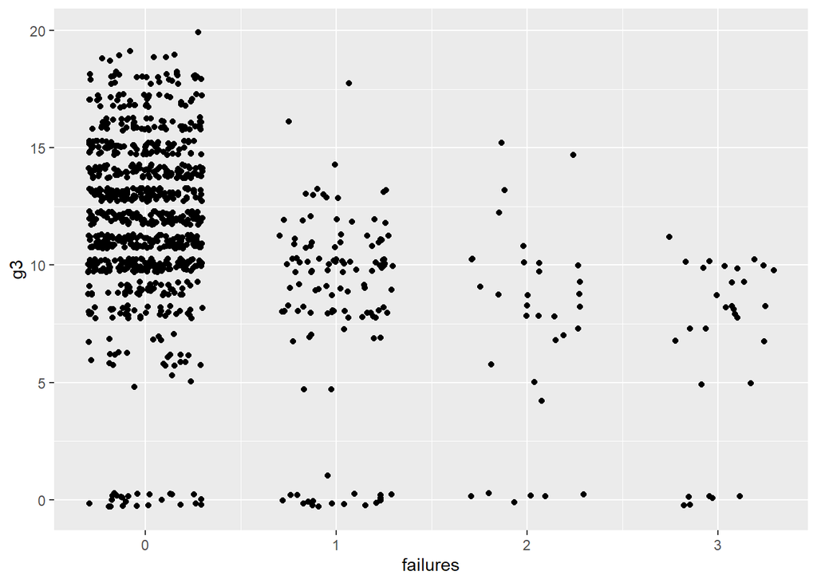

```r
plot7 <- ggplot ( data,aes ( x=failures,y=g3 ) ) +
geom_point ( position=position_jitter ( w=0.3,h=0.3) )
plot7
```

```r
round(tapply ( data$g3,data$failures,mean ),1)
```

```
##    0    1    2    3
## 12.1  8.4  7.5  6.8
```

**Relación edad + nota final + horas de estudio**

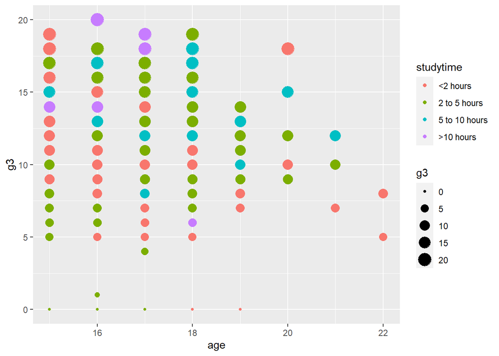

```r
g4 <- ggplot ( data,aes ( x=age,y=g3,color =studytime ) ) + geom_point ( aes ( size=g3 ) )

g4
```

Posteriormente se analiza la existencia de diferencias por fracaso en las notas y la media del resto de las variables numéricas.

```r
round(tapply ( data$g3,data$age,mean ),1)
```

```
##   15   16   17   18   19   20   21   22
## 11.7 11.6 11.6 11.0  9.0 12.7  9.7  6.5
```

```r
tapply ( data$absences,data$g3,mean )
```

```
##         0         1         4         5         6         7         8         9
##  0.000000  0.000000 22.000000 11.500000  8.277778  6.263158  7.865672  6.841270
##        10        11        12        13        14        15        16        17
##  4.797386  5.119205  3.786408  3.743363  3.766667  3.012195  3.115385  2.685714
##        18        19        20
##  3.666667  3.571429  4.000000
```

```r
tapply ( data$failures,data$g3,mean )
```

```
##          0          1          4          5          6          7          8
## 0.88679245 1.00000000 2.00000000 1.25000000 0.11111111 1.26315789 0.73134328
##          9         10         11         12         13         14         15
## 0.47619048 0.42483660 0.13245033 0.08737864 0.08849558 0.01111111 0.04878049
##         16         17         18         19         20
## 0.01923077 0.00000000 0.03703704 0.00000000 0.00000000
```

**Tablas de contingencia**

```r
table ( data$sex,data$schoolsup )
```

```
##
##           no yes
##   female 504  87
##   male   421  32
```

```r
table ( data$sex,data$famsup )
```

```
##
##           no yes
##   female 194 397
##   male   210 243
```

**Tabla de contingencia del sexo con respecto a la superación de la nota**

```r
X <- table ( data$sex, data$bing3 )
X
```

```
##
##          fail pass
##   female  125  466
##   male    105  348
```

**Se calcula la proporción**

```r
prop.table(X,1)
```

```
##
##               fail      pass
##   female 0.2115059 0.7884941
##   male   0.2317881 0.7682119
```

# Segmentar los datos: K-Means

Para realizar una identificación de los estudiantes que posiblemente tienen una relación fuerte con el acohol y de eso depende las notas académicas, se aplicará la técnica de segmentación por medio de K-means para lograr agrupar la población de estudiantes con este comportamiento y que las autoridades académicas empleen métodos de mejora de actitud en cuanto al consumo de alcohol.

#### Desarrollo

```r
variables_numericas
```

```
## [1] "age"      "failures" "absences" "g1"       "g2"       "g3"       "alcohol"
```

#### Variables cluster

```r
variables_cluster<-c("age","failures","absences","g1","g2","g3")
```

Se utiliza el data set el cuál se le realizó la limpieza en los pasos anteriores.

```r
data_cluster<-data_clean[variables_cluster]
head(data_cluster)
```

| age | failures | absences | g1 | g2 | g3 |
| --- | --- | --- | --- | --- | --- |
| 18 | 0 | 6 | 5 | 6 | 6 |
| 17 | 0 | 4 | 5 | 5 | 6 |
| 15 | 3 | 10 | 7 | 8 | 10 |
| 15 | 0 | 2 | 15 | 14 | 15 |
| 16 | 0 | 4 | 6 | 10 | 10 |
| 16 | 0 | 10 | 15 | 15 | 15 |

Se crea un dataframe donde se guardarán los datos normalizados, y luego se sustituyen las columnas de data_cluster por las columnas del data frame normalizado.

```r
data_cluster_norm<-data_cluster

data_cluster_norm[,c("age")] <- (data_cluster$age-mean(data_cluster$age))/sd(data_cluster$age)

  data_cluster_norm[,c("failures")] <- (data_cluster$failures-mean(data_cluster$failures))/sd(data_cluster$failures)

  data_cluster_norm[,c("absences")] <- (data_cluster$absences-mean(data_cluster$absences))/sd(data_cluster$absences)

  data_cluster_norm[,c("g1")] <- (data_cluster$g1-mean(data_cluster$g1))/sd(data_cluster$g1)

  data_cluster_norm[,c("g2")] <- (data_cluster$g2-mean(data_cluster$g2))/sd(data_cluster$g2)

  data_cluster_norm[,c("g3")] <- (data_cluster$g3-mean(data_cluster$g3))/sd(data_cluster$g3)
```

# K-Means

Se sabe que K-Means (traducido como K-Medias en español), es un método de agrupamiento o clustering.

El clustering es una técnica para encontrar y clasificar K grupos de datos (clusters). Así, los elementos que comparten características semejantes estarán juntos en un mismo grupo, separados de los otros grupos con los que no comparten características.

Para saber si los datos son parecidos o diferentes el algoritmo K-medias utiliza la distancia entre los datos. Las observaciones que se parecen tendrán una menor distancia entre ellas. En general, como medida se utiliza la distancia euclideana aunque también se pueden utilizar otras funciones.

## Entendimiento del funcionamiento del algoritmo de k-means

Los algoritmos de clustering son considerados de aprendizaje no supervisado. Este tipo de algoritmos de aprendizaje no supervisado busca patrones en los datos sin tener una predicción específica como objetivo (no hay variable dependiente). En lugar de tener una salida, los datos solo tienen una entrada que serían las múltiples variables que describen los datos.

K-means necesita como dato de entrada el número de grupos en los que vamos a segmentar la población. A partir de este número k de clusters, el algoritmo coloca primero k puntos aleatorios (centroides). Luego asigna a cualquiera de esos puntos todas las muestras con las distancias más pequeñas.

A continuación, el punto se desplaza a la media de las muestras más cercanas. Esto generará una nueva asignación de muestras, ya que algunas muestras están ahora más cerca de otro centroide. Este proceso se repite de forma iterativa y los grupos se van ajustando hasta que la asignación no cambia más moviendo los puntos. Este resultado final representa el ajuste que maximiza la distancia entre los distintos grupos y minimiza la distancia intragrupo.

- los centros de grupos
- la suma de cuadrados totales,
- la suma de cuadrados dentro de cada grupo
- La suma de cuadrados entre grupos

```r
set.seed(123)
clus2_k3<-kmeans(data_cluster_norm,centers=3)
clus2_k3$centers
```

```
##          age   failures    absences         g1         g2         g3
## 1 -0.1137588 -0.2816977  0.20064553 -0.4179380 -0.3117998 -0.2026738
## 2 -0.1492691 -0.3354576 -0.25601065  0.9847198  0.9201951  0.8487943
## 3  0.7008034  1.6507186  0.05043198 -1.2234992 -1.3724723 -1.5131042
```

```r
clus2_k3$totss
```

```
## [1] 5934
```

```r
clus2_k3$withinss
```

```
## [1] 1221.9351  945.5809 1136.7126
```

```r
clus2_k3$tot.withinss
```

```
## [1] 3304.229
```

```r
clus2_k3$betweenss
```

```
## [1] 2629.771
```

# Elección del número de clústers

Luego de entender el concepto de la metodología K- means, a partir de los datos se buscará el k que haga que los individuos que pertenecen a un mismo grupo sean lo mas homogéneo posible y los individuos pertenecientes a distintos grupos sean lo mas heterogéneos posible

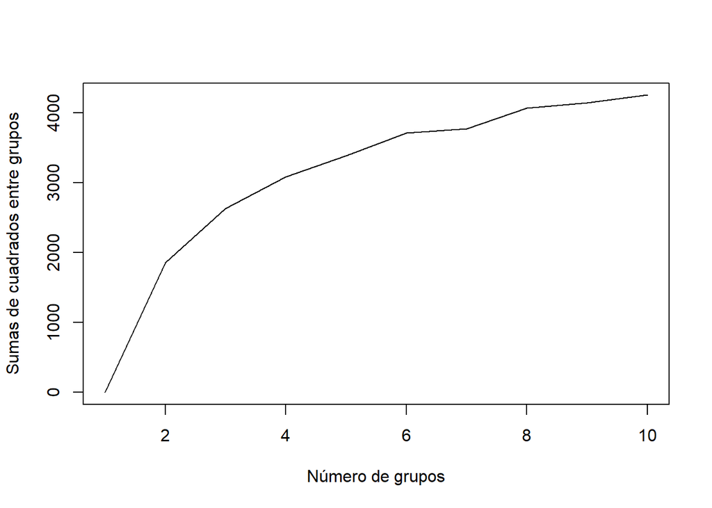

```r
set.seed(123)
bss <- kmeans(data_cluster_norm,centers=1)$betweenss
 for (i in 2:10) bss[i] <- kmeans(data_cluster_norm,centers=i)$betweenss
plot(1:10, bss, type="l", xlab="Número de grupos",ylab="Sumas de cuadrados entre grupos")
```

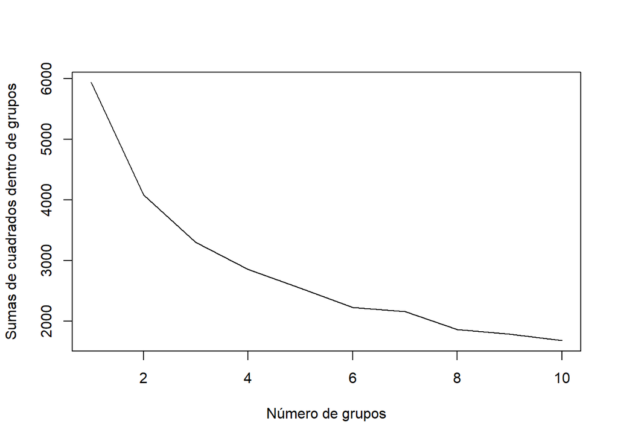

```r
set.seed(123)
tw <- kmeans(data_cluster_norm,centers=1)$tot.withinss
 for (i in 2:10) tw[i] <- kmeans(data_cluster_norm,centers=i)$tot.withinss

plot(1:10, tw, type="l", xlab="Número de grupos",ylab="Sumas de cuadrados dentro de grupos")
```

### Se unen los dos gráficos para la comparación

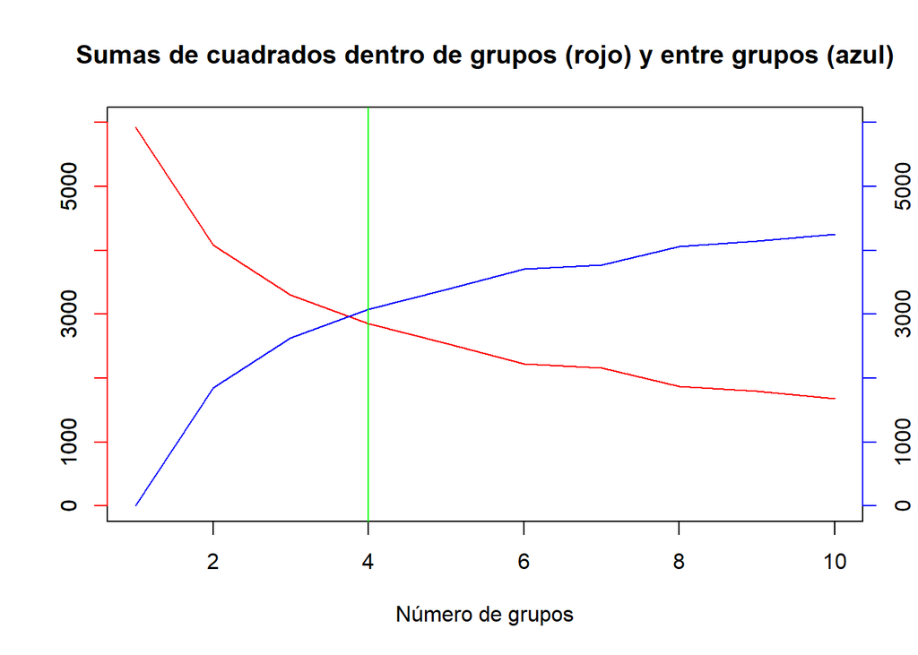

```r
{
  plot(1:10, tw, type="l",col="red", xlab="",ylab="", ylim=c(0,6000))
  axis(side=2, col="red")
  par(new=TRUE)
  plot(1:10, bss, type="l",col="blue", xlab="Número de grupos",ylab="", ylim=c(0,6000), axes=FALSE)
  axis(side=4, col="blue")
  title(main="Sumas de cuadrados dentro de grupos (rojo) y entre grupos (azul)")
  abline(v=4, col="green")
}
```

Se evidencia que para k=4 se obtiene un punto de equilibrio entre el número de grupos.

# Segmentación óptima

Según el modelo, indica que el número óptimo de clústers es 4 por lo tanto se procede a realizar la clasificación con los individuos seleccionados

```r
set.seed(123)
clus2_k4<-kmeans(data_cluster_norm,centers=4)
clus2_k4$centers
```

```
##           age    failures   absences         g1         g2          g3
## 1 -0.37112956 -0.31331189 -0.3662657 -0.2636858 -0.1797850 -0.08902886
## 2 -0.05822964 -0.35271962 -0.2018769  1.1216816  1.0609857  0.97170737
## 3  0.55532301  0.04047577  1.5471874 -0.5533374 -0.4643038 -0.34737106
## 4  0.59404543  1.80702536 -0.3516457 -1.2245341 -1.4543367 -1.67124877
```

```r
clus2_k4$totss
```

```
## [1] 5934
```

```r
clus2_k4$withinss
```

```
## [1] 706.9261 712.8139 542.9994 890.9655
```

```r
clus2_k4$tot.withinss
```

```
## [1] 2853.705
```

```r
clus2_k4$betweenss
```

```
## [1] 3080.295
```

## Asignación de clústers

```r
names(data_cluster_norm)<-c("age_st","failures_st","absences_st", "g1_st", "g2_st", "g3_st")
data_cluster_result<-data.frame(data_cluster, data_cluster_norm, as.factor(clus2_k4$cluster), data_clean$alcohol)
#names(data_cluster_result)[15]<-"cluster"
names(data_cluster_result)[13]<-"cluster"
names(data_cluster_result)[14]<-"alcohol"
head(data_cluster_result)
```

|  | age | failures | absences | g1 | g2 | g3 | age_st | failures_st | absences_st | g1_st | g2_st | g3_st | cluster | alcohol |
| --- | --- | --- | --- | --- | --- | --- | --- | --- | --- | --- | --- | --- | --- | --- |
| 1 | 18 | 0 | 6 | 5 | 6 | 6 | 1.0640333 | -0.3876334 | 0.6787848 | -2.088010 | -1.6070407 | -1.3840741 | 3 | 1.00 |
| 2 | 17 | 0 | 4 | 5 | 5 | 6 | 0.2480821 | -0.3876334 | 0.1509003 | -2.088010 | -1.9100250 | -1.3840741 | 4 | 1.00 |
| 3 | 15 | 3 | 10 | 7 | 8 | 10 | -1.3838203 | 4.2359454 | 1.7345538 | -1.419685 | -1.0010722 | -0.3584503 | 4 | 2.29 |
| 4 | 15 | 0 | 2 | 15 | 14 | 15 | -1.3838203 | -0.3876334 | -0.3769842 | 1.253616 | 0.8168333 | 0.9235794 | 2 | 1.00 |
| 5 | 16 | 0 | 4 | 6 | 10 | 10 | -0.5678691 | -0.3876334 | 0.1509003 | -1.753848 | -0.3951037 | -0.3584503 | 1 | 1.29 |
| 6 | 16 | 0 | 10 | 15 | 15 | 15 | -0.5678691 | -0.3876334 | 1.7345538 | 1.253616 | 1.1198176 | 0.9235794 | 2 | 1.29 |

## Gráficos de clúster

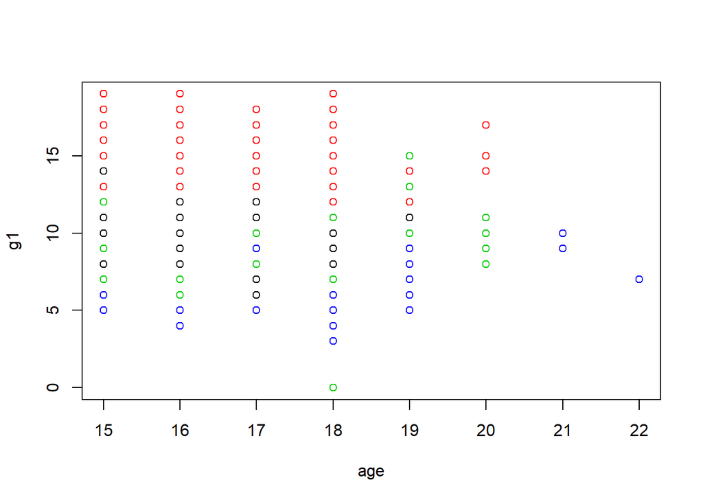

```r
plot(data_cluster_result[c("age", "g1")], col=data_cluster_result$cluster)
```

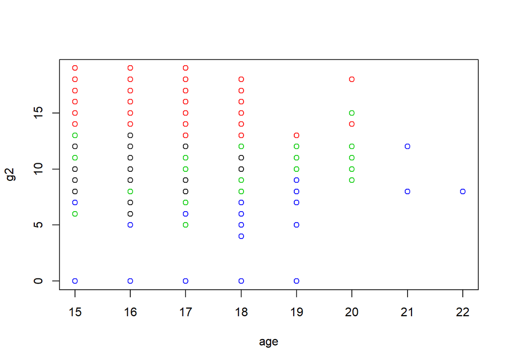

```r
plot(data_cluster_result[c("age", "g2")], col=data_cluster_result$cluster)
```

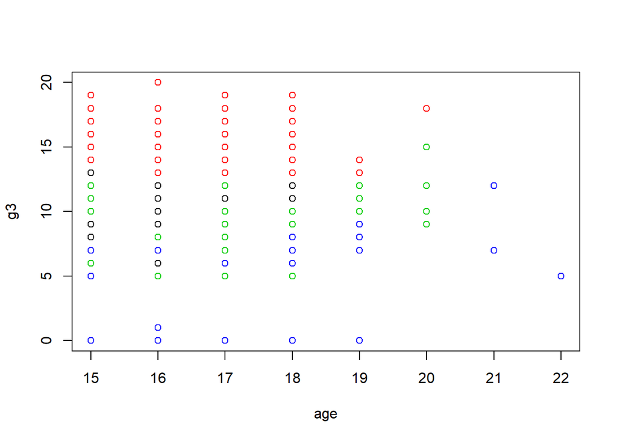

```r
plot(data_cluster_result[c("age", "g3")], col=data_cluster_result$cluster)
```

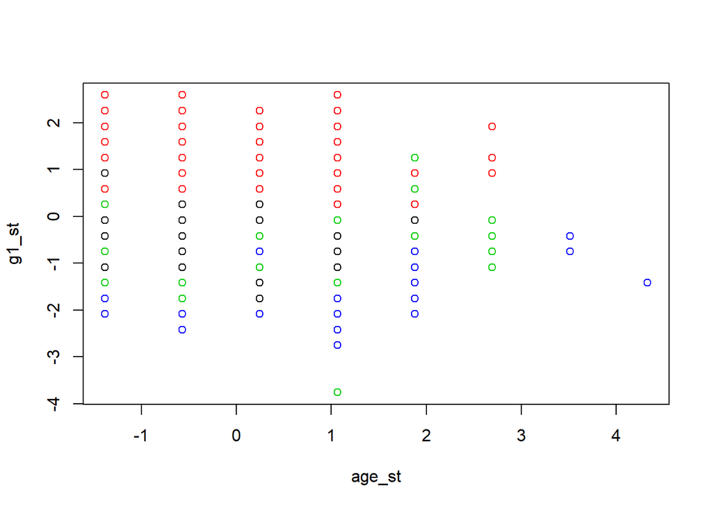

```r
plot(data_cluster_result[c("age_st", "g1_st")], col=data_cluster_result$cluster)
```

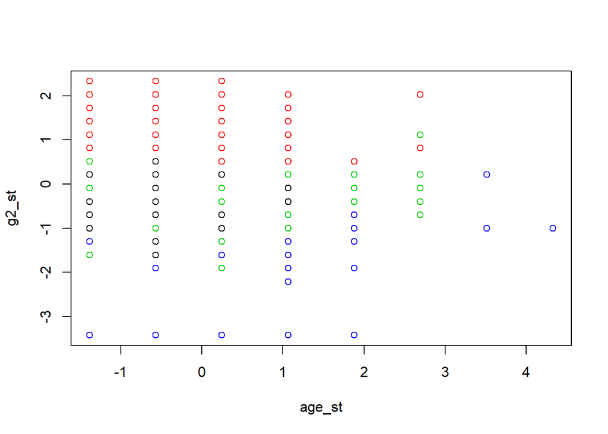

```r
plot(data_cluster_result[c("age_st", "g2_st")], col=data_cluster_result$cluster)
```

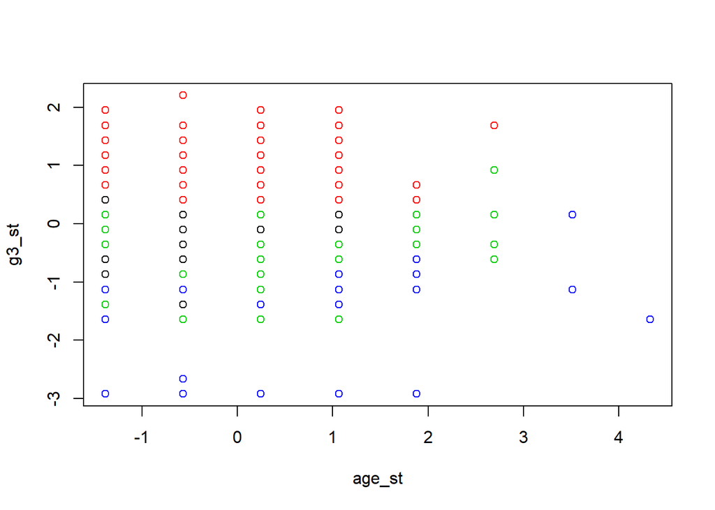

```r
plot(data_cluster_result[c("age_st", "g3_st")], col=data_cluster_result$cluster)
```

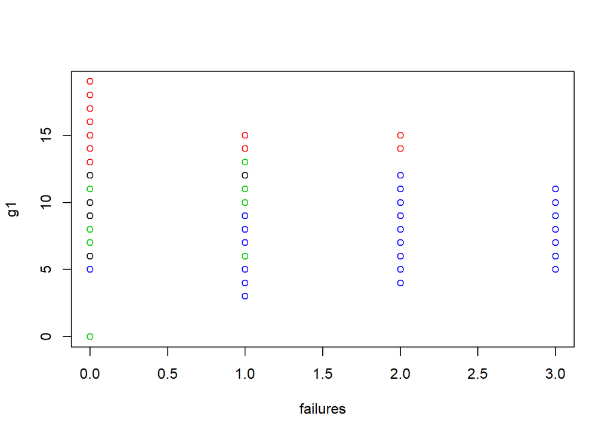

```r
plot(data_cluster_result[c("failures", "g1")], col=data_cluster_result$cluster)
```

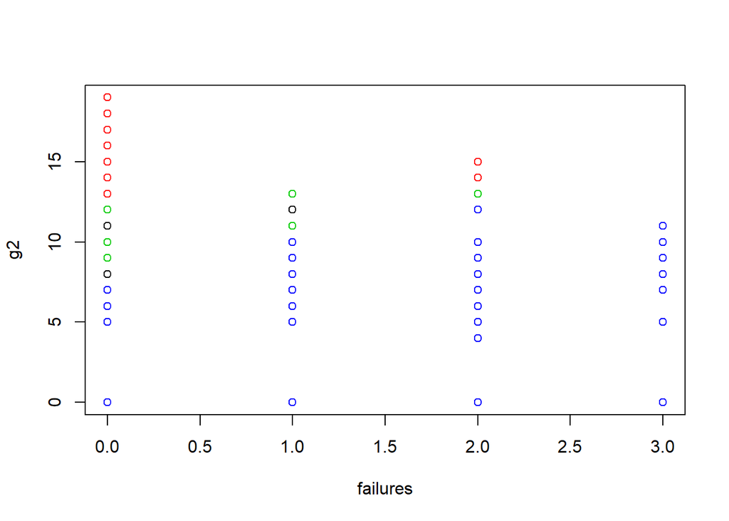

```r
plot(data_cluster_result[c("failures", "g2")], col=data_cluster_result$cluster)
```

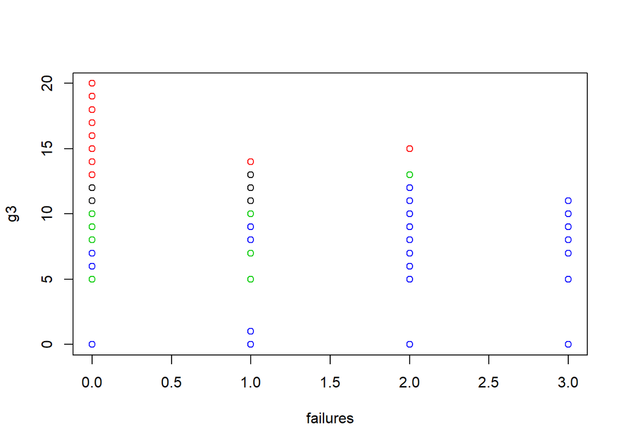

```r
plot(data_cluster_result[c("failures", "g3")], col=data_cluster_result$cluster)
```

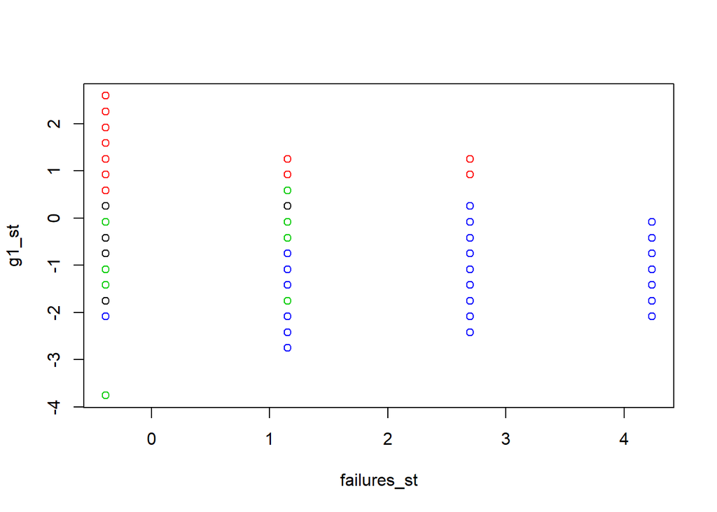

```r
plot(data_cluster_result[c("failures_st", "g1_st")], col=data_cluster_result$cluster)
```

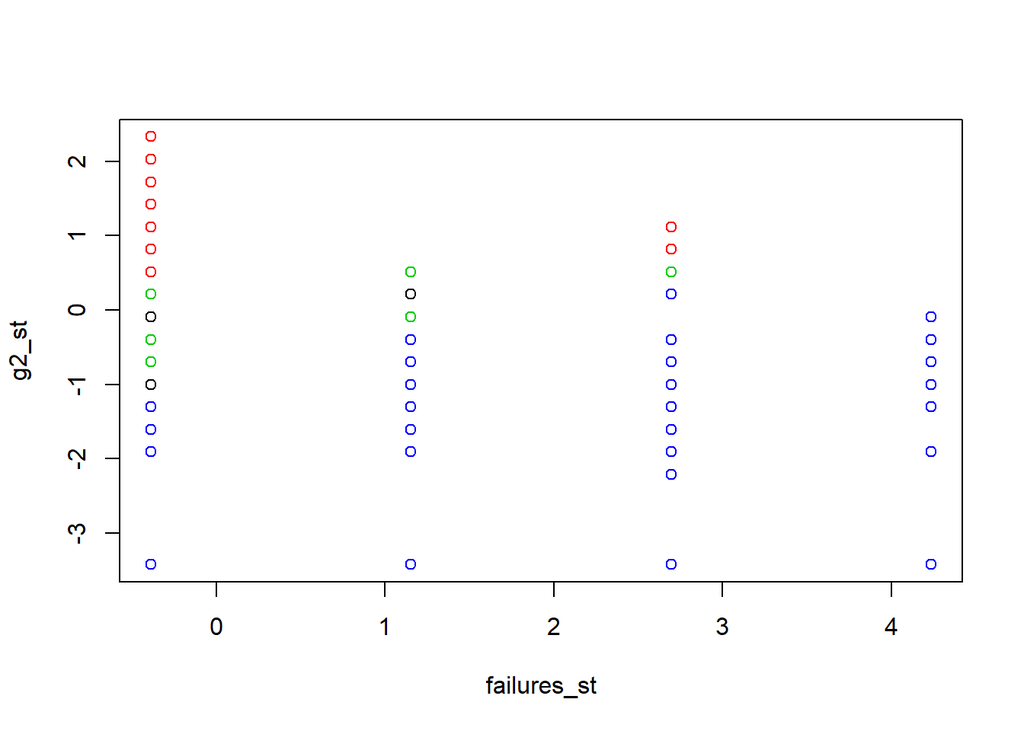

```r
plot(data_cluster_result[c("failures_st", "g2_st")], col=data_cluster_result$cluster)
```

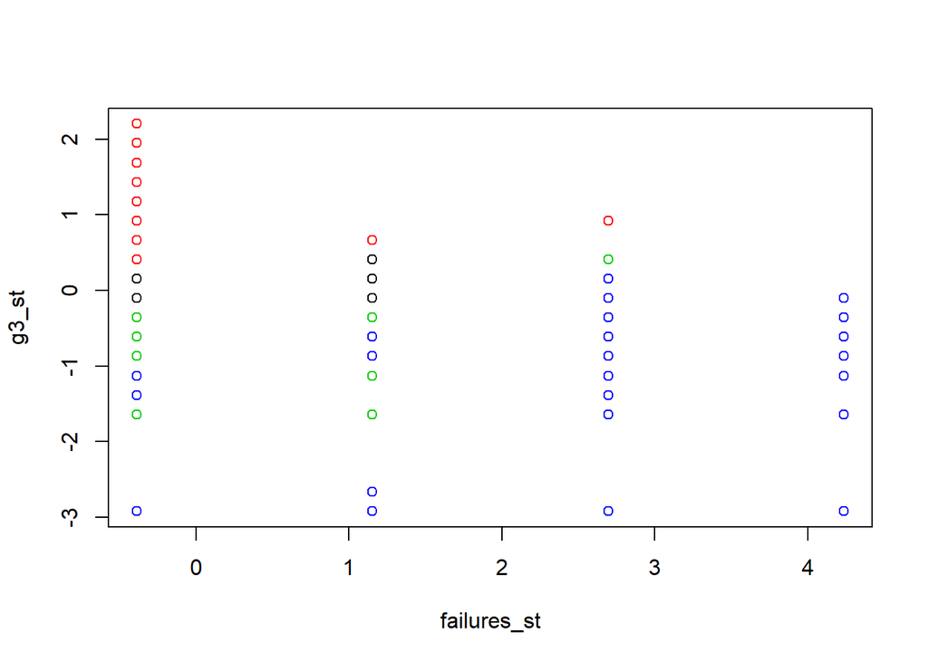

```r
plot(data_cluster_result[c("failures_st", "g3_st")], col=data_cluster_result$cluster)
```

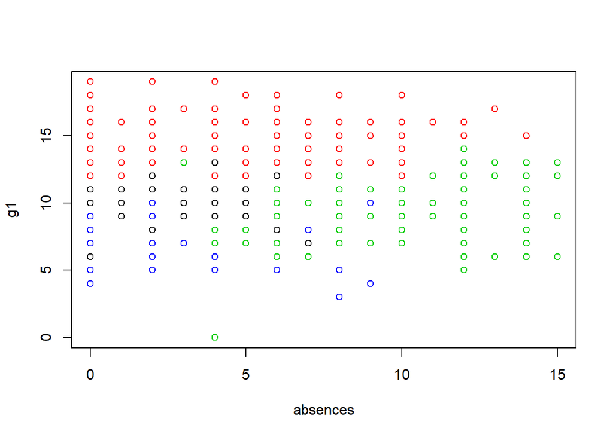

```r
plot(data_cluster_result[c("absences", "g1")], col=data_cluster_result$cluster)
```

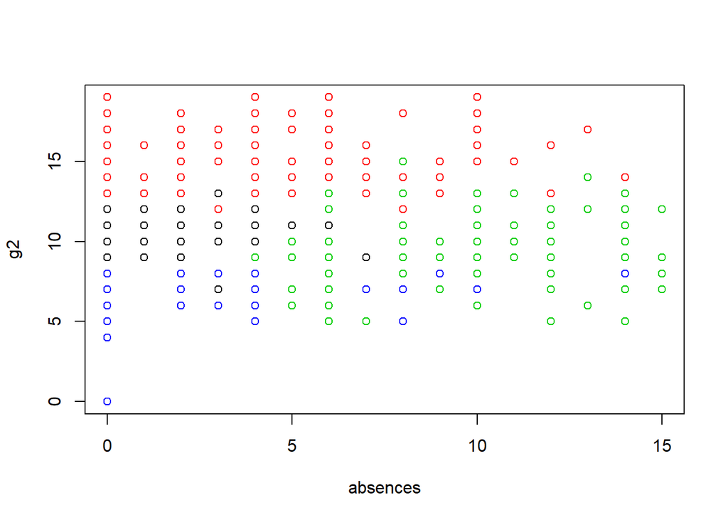

```r
plot(data_cluster_result[c("absences", "g2")], col=data_cluster_result$cluster)
```

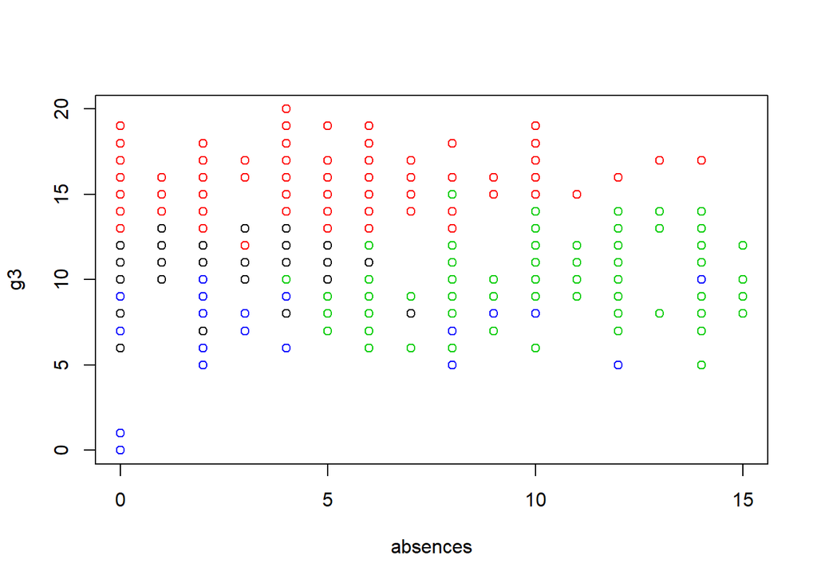

```r
plot(data_cluster_result[c("absences", "g3")], col=data_cluster_result$cluster)
```

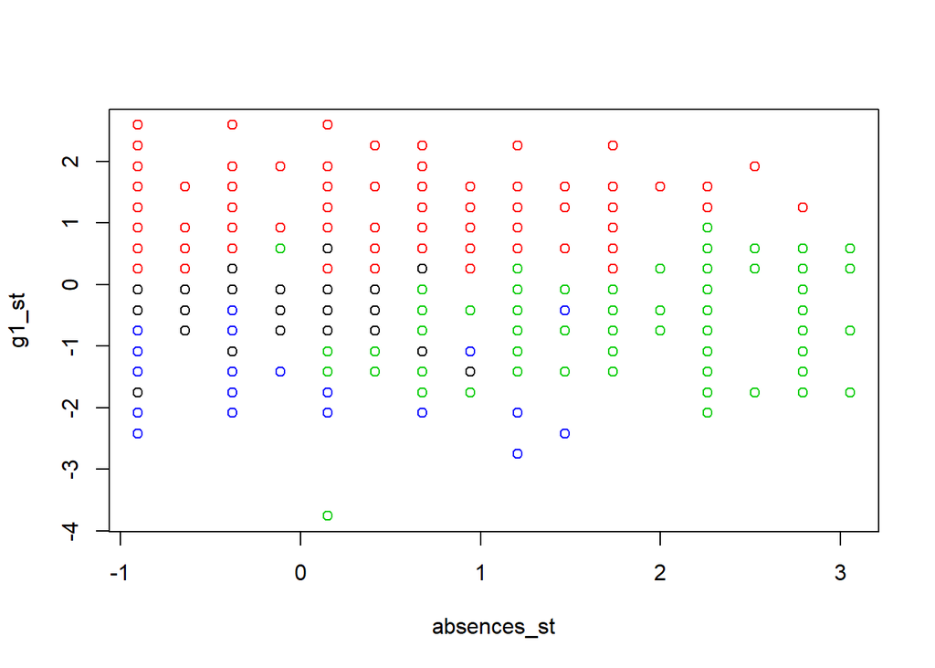

```r
plot(data_cluster_result[c("absences_st", "g1_st")], col=data_cluster_result$cluster)
```

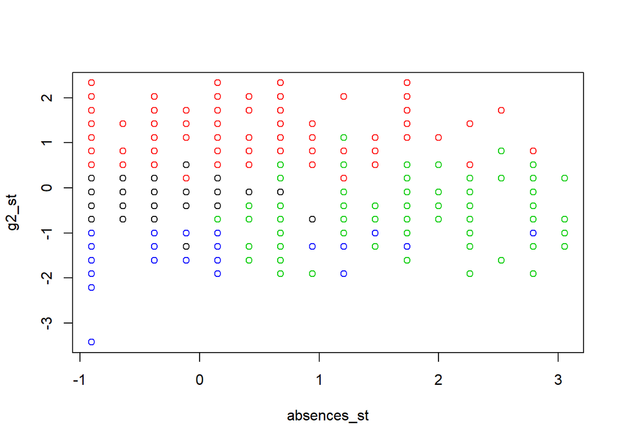

```r
plot(data_cluster_result[c("absences_st", "g2_st")], col=data_cluster_result$cluster)
```

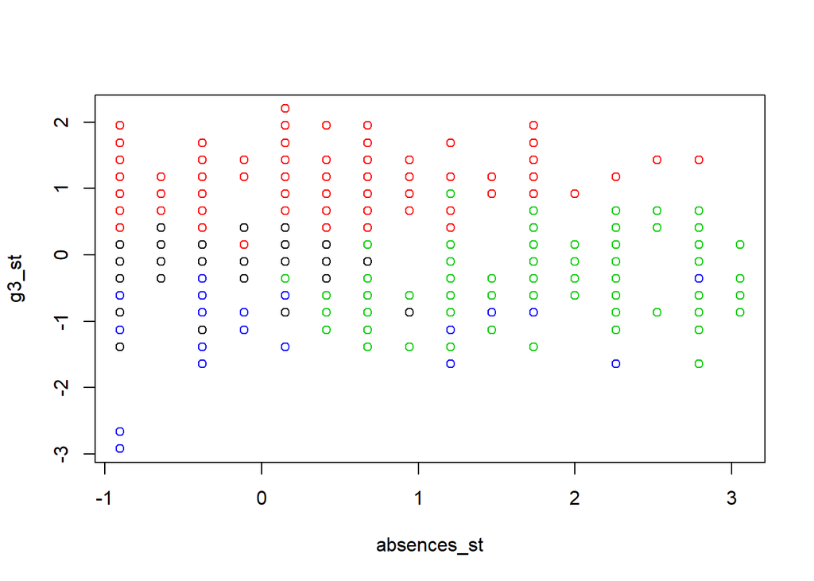

```r
plot(data_cluster_result[c("absences_st", "g3_st")], col=data_cluster_result$cluster)
```

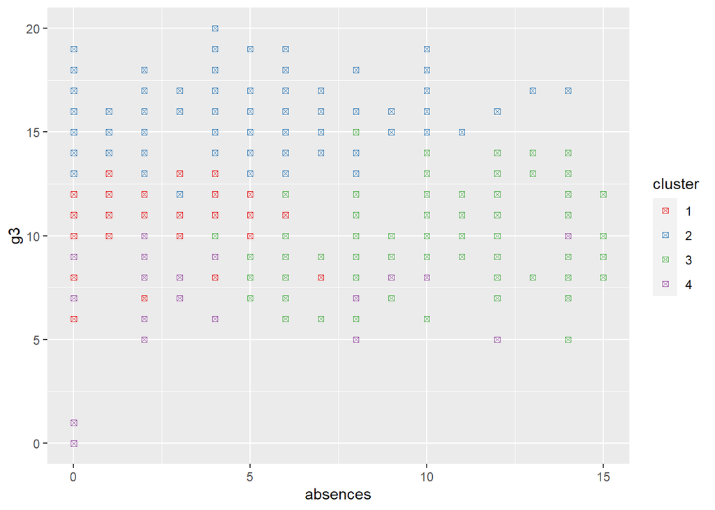

```r
grafico_cluster<-ggplot(data_cluster_result, aes(x=absences, y=g3, color=cluster)) + geom_point(shape=7)+scale_color_brewer(palette="Set1")
grafico_cluster
```

```r
rm(i)
rm(clus2_k3)
#save.image("mywspace_TFM.RData")
clus2_k4$centers
```

```
##           age    failures   absences         g1         g2          g3
## 1 -0.37112956 -0.31331189 -0.3662657 -0.2636858 -0.1797850 -0.08902886
## 2 -0.05822964 -0.35271962 -0.2018769  1.1216816  1.0609857  0.97170737
## 3  0.55532301  0.04047577  1.5471874 -0.5533374 -0.4643038 -0.34737106
## 4  0.59404543  1.80702536 -0.3516457 -1.2245341 -1.4543367 -1.67124877
```

```r
tapply ( data_cluster_result$alcohol,data_cluster_result$cluster,mean )
```

```
##        1        2        3        4
## 1.697107 1.463042 2.029198 1.869440
```

# Agrupación de cluster

Se realiza una agrupación por clúster para observar la distribución de cada uno

```r
table(data_cluster_result$cluster)
```

```
##
##   1   2   3   4
## 394 309 162 125
```

```r
sort(prop.table(table(data_cluster_result$cluster))*100, decreasing = T)
```

```
##
##        1        2        3        4
## 39.79798 31.21212 16.36364 12.62626
```

```r
G<-data_cluster_result %>% select(cluster, age  , failures  , g1, g2, g3, alcohol) %>% group_by(cluster) %>% summarise(AVG_Alcohol= mean(alcohol, na.rm = TRUE), AVG_age=mean(age, na.rm = TRUE), AVG_Failures=mean(failures, na.rm = TRUE) )

G
```

| cluster | AVG_Alcohol | AVG_age | AVG_Failures |
| --- | --- | --- | --- |
| 1 | 1.697107 | 16.24112 | 0.04822335 |
| 2 | 1.463042 | 16.62460 | 0.02265372 |
| 3 | 2.029198 | 17.37654 | 0.27777778 |
| 4 | 1.869440 | 17.42400 | 1.42400000 |

## Conclusion e interpretación final

- Se identificaron 4 posibles clústers de estudiantes con diferentes características que pueden afectar el rendimiento académico y luego de identificarlo se deben realizar estrategias de adopción de nuevas actividades para mejorar las notas.

- Las variables que posiblemente insiden en el rendimiento son el consumo de alcohol, en relación con la edad y las faltas de clase.

- El 31% de los estudiantes se encuentran en el clúster 2, en este se regisrta una edad promedio de 16 años incluyendo edades de 15, con menos consumo de alcohol y con inasistencia del 3 % con respecto al año académico.

- El análisis no supervisado nos da una gran claridad en el tema de segmentación por medio de la metodología k-means.Esta ayuda en la identificación de grupos con características especiales y así poder crear estrategias mas profundas para la mejora de resultados según la población en cada clúster.

- Con este análisis se puede concluir además que es un gran ejemplo para el tema de desbalance de clases dado que se presentan diferentes proporciones en algunas variables categóricas que son de interés para los resultados del modelo.